title: “OOP Investigation” date: “02/06/2015” output: html_document: toc: true toc_depth: 4 number_sections: true

# 1 Background

## 1.1 Driving Questions from JM Thome:

- Analysis and correlation ( especially for the public health facilities ) of
  - general out-of-pocket health expenditure
    - OOP (Q3.3)
    - ( 3.5, 3.7),
  - FMNCH expenditure
    - Child Admittance (Q7.8.7-7.16)
      - OOP
      - Food
      - Transport
    - Mothers ( Q4.10, 4.18, 4.20, 5.18, 5.23, 5.28)
      - ANC OOP
      - Birth Cost
      - Birth Food Allowance
      - Birth Transport
  - HEF OOP expenditure (Q8.8-8.16)
- Analysis of the main drivers of OOP payment for FMNCH services and for HEF members

# 2 General out-of-pocket health expenditure

## 2.1 Outpatient (Q3.3)

```
## [1] "HH_Illness_2_National_Hospital_cost_Overall_average"
## [2] "HH_Illness_2_Provincial_Hospital_cost_Overall_average"
## [3] "HH_Illness_2_Health_Center_cost_Overall_average"
## [4] "HH_Illness_2_Private_Clinic_cost_Overall_average"
```

## 2.2 Inpatient (3.5,3.7)

# 3 FMNCH expenditure

## 3.1 Child Addmitance event (Q7.8.7-7.16)

- OOP Rates
- Cost Breakdown
- Food Allowances
- Transport Allowances

### 3.1.1 OOP Rates

82 Families reported a child inpatient event.

Child addmittance events

|  | PreID | GeoID | NoAssist | All |
| --- | --- | --- | --- | --- |
| Num Child Admit | 27 | 26 | 29 | 82 |

The largers group of inpatient events are the GeoID in the distric hospitals.

Child Inpatient Report Counts by Facitly and Insurrance Group

|  | PreID | GeoID | NoAssist | All |
| --- | --- | --- | --- | --- |
| PH | 8 | 1 | 13 | 22 |
| DH | 13 | 22 | 11 | 46 |
| HC | 6 | 3 | 4 | 13 |
| Other | 0 | 0 | 1 | 1 |
| Total | 27 | 26 | 29 | 82 |

#### 3.1.1.1 Barplot of OOP by facilty and Insurance Type

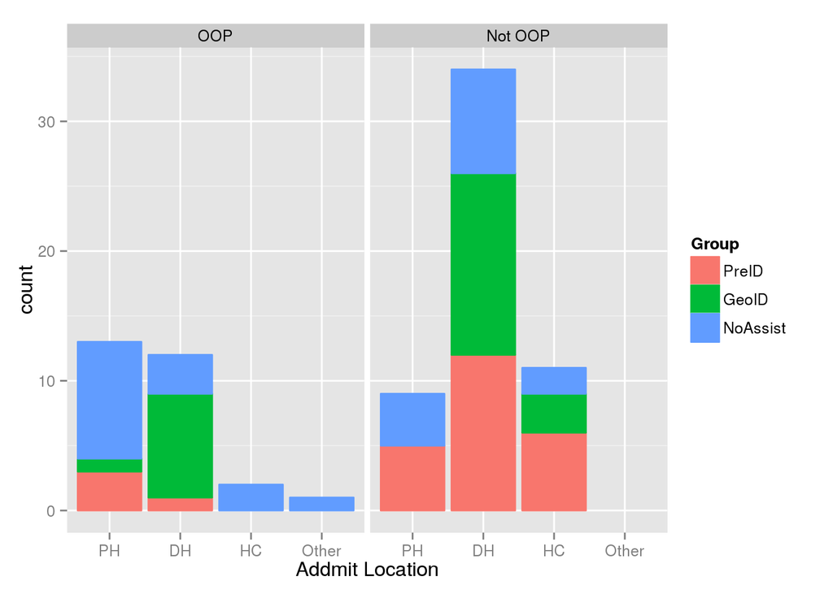

OOP Percentages for Child Inpatient Reports by Facitly and Insurrance Group

|  | PreID | GeoID | NoAssist | All |
| --- | --- | --- | --- | --- |
| PH | 37.5 | 100.0 | 69.2 | 59.1 |
| DH | 7.7 | 36.4 | 27.3 | 26.1 |
| HC | 0.0 | 0.0 | 50.0 | 15.4 |
| Other | NaN | NaN | 100.0 | 100.0 |
| Total | 14.8 | 34.6 | 51.7 | 34.1 |

### 3.1.2 Cost Breakdown

Overview plot of cost breakdowns for all child inpatient procedures reported

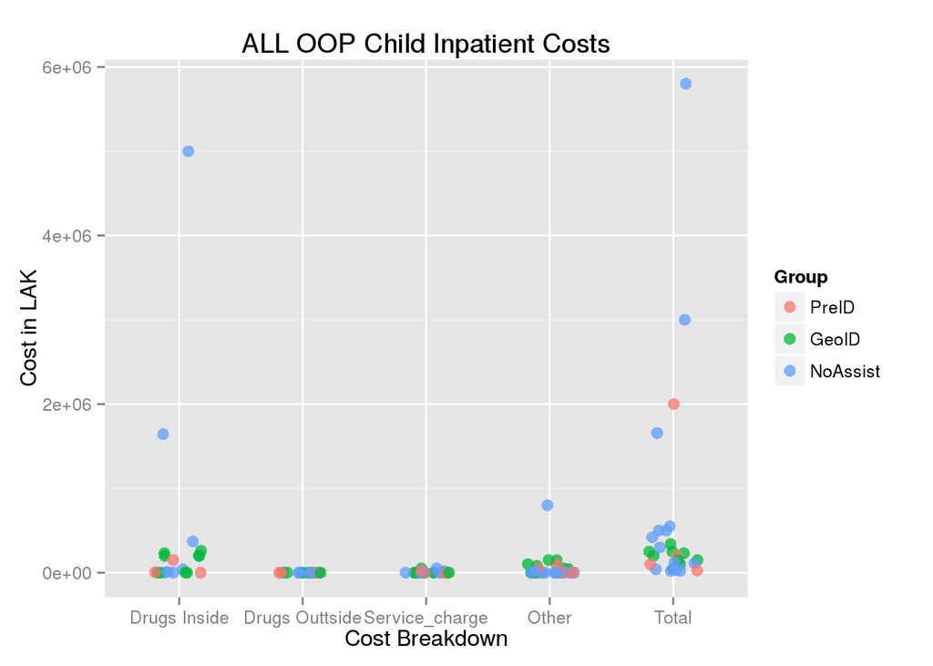

Remove outliers and break down by care facility:

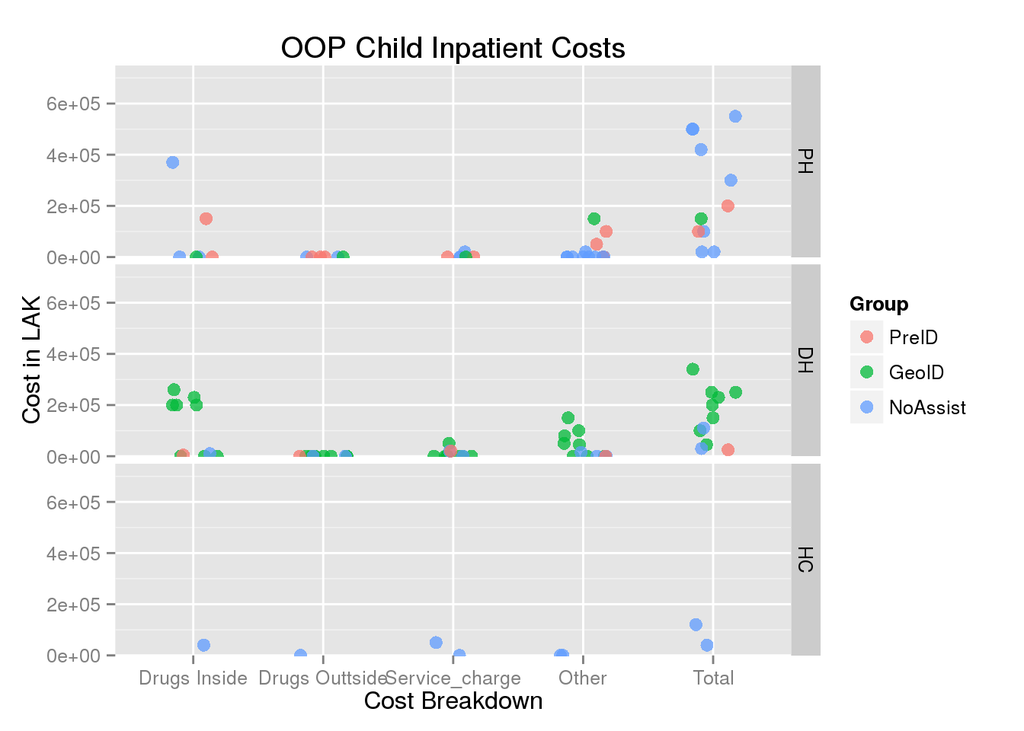

### 3.1.3 Food Allowances

#### 3.1.3.1 Number of casses that recieve food allowances

Number of Food Allowances by facility and Insurance type

|  | PreID | GeoID | NoAssist | All |
| --- | --- | --- | --- | --- |
| PH | 3 | 1 | 0 | 4 |
| DH | 8 | 14 | 2 | 24 |
| HC | 0 | 0 | 0 | 0 |
| Other | 0 | 0 | 0 | 0 |

#### 3.1.3.2 Percent of casses that recieve food allowances

Percent of Food Allowances by facility and Insurance type

|  | PreID | GeoID | NoAssist | All |
| --- | --- | --- | --- | --- |
| PH | 37.5 | 100.0 | 0.0 | 18.2 |
| DH | 61.5 | 63.6 | 18.2 | 52.2 |
| HC | 0.0 | 0.0 | 0.0 | 0.0 |
| Other | NaN | NaN | 0.0 | 0.0 |

#### 3.1.3.3 Plot of Food Allowance Amounts

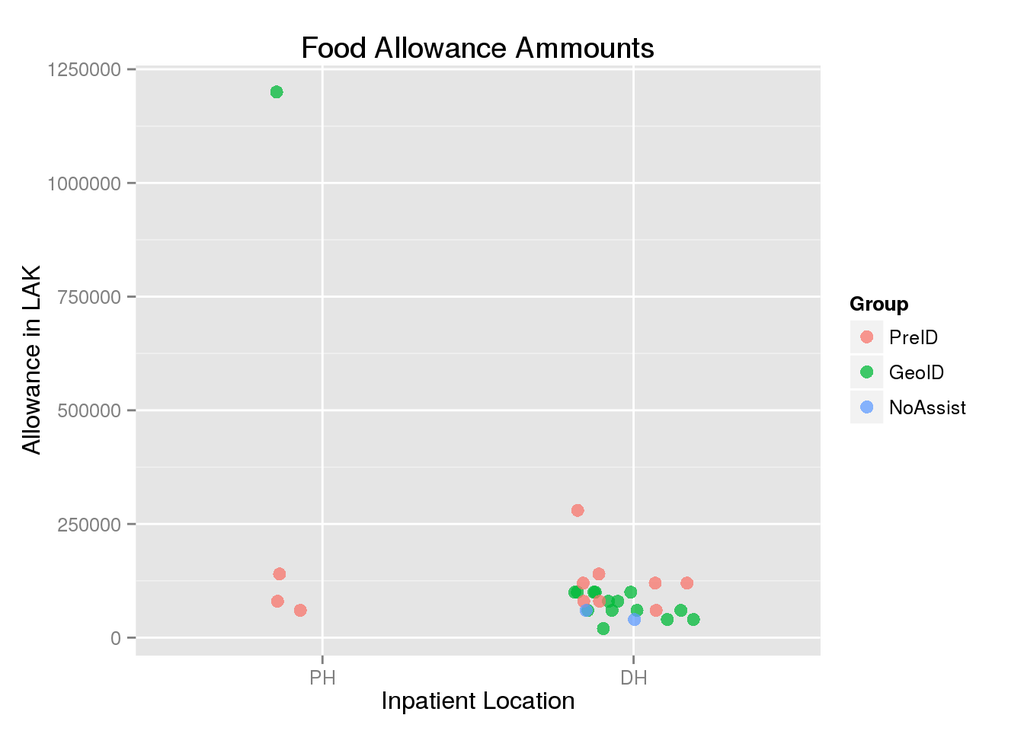

### 3.1.4 Transportation Allowances

#### 3.1.4.1 Overview of Transportation Allowance Reception for Child hospitalizations

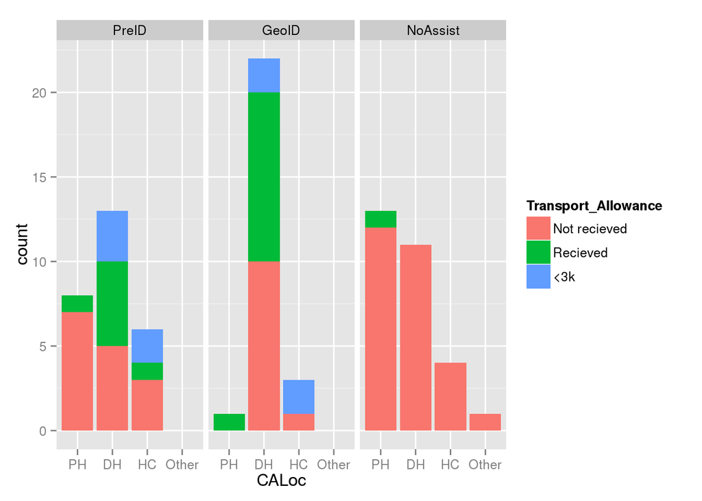

#### 3.1.4.2 Number of casses that recieve transportation allowance

Number of Transportation Allowances Recieved facility and Insurance type

|  | PH | DH | HC | Other |
| --- | --- | --- | --- | --- |
| PreID | 1 | 5 | 1 | 0 |
| GeoID | 1 | 10 | 0 | 0 |
| NoAssist | 1 | 0 | 0 | 0 |
| All | 3 | 15 | 1 | 0 |

#### 3.1.4.3 Percent of casses that recieve transportation allowance

Percent of Transportation Allowances Recieved by facility and Insurance type

|  | PreID | GeoID | NoAssist | All |
| --- | --- | --- | --- | --- |
| PH | 12.5 | 100.0 | 7.7 | 13.6 |
| DH | 38.5 | 45.5 | 0.0 | 32.6 |
| HC | 16.7 | 0.0 | 0.0 | 7.7 |
| Other | NaN | NaN | 0.0 | 0.0 |

#### 3.1.4.4 Number of casses within 3km

Number <3km (no transport) by Facility and Insurance type

|  | PH | DH | HC | Other |
| --- | --- | --- | --- | --- |
| PreID | 0 | 3 | 2 | 0 |
| GeoID | 0 | 2 | 2 | 0 |
| NoAssist | 0 | 0 | 0 | 0 |
| All | 0 | 5 | 4 | 0 |

#### 3.1.4.5 Percent of casses within 3km

Percent <3km (no transport) by Facility and Insurance type

|  | PreID | GeoID | NoAssist | All |
| --- | --- | --- | --- | --- |
| PH | 0.0 | 0.0 | 0.0 | 0.0 |
| DH | 23.1 | 9.1 | 0.0 | 10.9 |
| HC | 33.3 | 66.7 | 0.0 | 30.8 |
| Other | NaN | NaN | 0.0 | 0.0 |

#### 3.1.4.6 Plot Transportation Amount Recieved

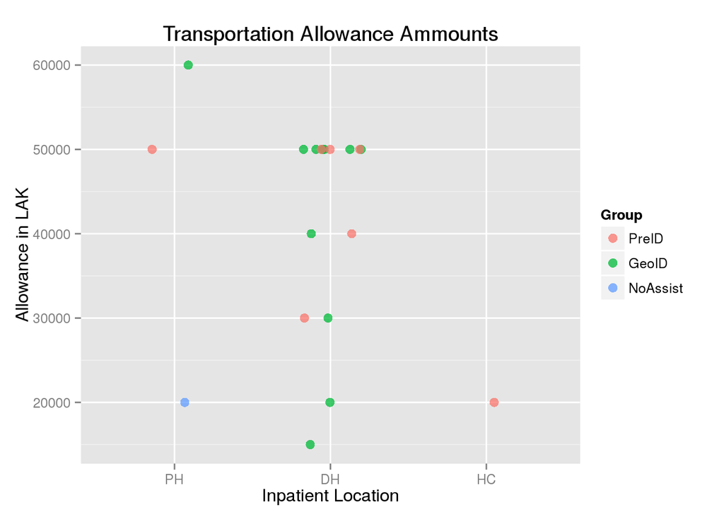

## 3.2 MNCH Rates (Q4.10, 4.18, 4.20)

- Mother OOP ANCs (Q4.10)
- Birth Cost delivery (4.18)
- Birth Hospital Food allowance (4.20)
- Birth Delivery was at hospital more 3k

### 3.2.1 OOP ANCs (Q4.10)

```r
#Monthers who have not been to ANC have NA
#Mothers$Mother_been_to_ANC[is.na(Mothers$Mother_OOP_ANCs)]
ANCM <- subset(Mothers,!is.na(Mothers$Mother_OOP_ANCs))

#Count the number of ANC Mothers
sapply(levels(ANCM$Group),function(G){sum(!is.na(subset(ANCM,Group==G)[,1]))})
```

```
##    PreID    GeoID NoAssist
##       60       73      148
```

```r
#Number of ANC Mothers that had a child admitance event
sum(ANCM$Serial%in%CA$Serial)
```

```
## [1] 36
```

```r
#Number of Mothers reporting ANC OOP
sapply(levels(Mothers$Group),function(G){sum(subset(ANCM,Group==G)[,"Mother_OOP_ANCs"]==1)})
```

```
##    PreID    GeoID NoAssist
##        1        1        7
```

```r
#Number of Mothers reporting ANC OOP having a child admitance event report
sapply(levels(Mothers$Group),function(G){sum(subset(ANCM,Group==G & Serial%in%CA$Serial )[,"Mother_OOP_ANCs"]==1)})
```

```
##    PreID    GeoID NoAssist
##        0        1        1
```

```r
#Number of Mothers reporting ANC OOP having a child admitance event report reporting OOP
sapply(levels(Mothers$Group),function(G){
  sum(subset(ANCM,Group==G &
                          Mother_OOP_ANCs==1 &
                          Serial%in%CA$Serial
             )[,"Child_Admitted_Cost_OOP"]==1
      )})
```

```
##    PreID    GeoID NoAssist
##        0        0        0
```

The 2 women who paid ANCs out of pocket and had inpatient child events in the same familly did not claim out of pocket payments on these children

### 3.2.2 Cost of Delivery

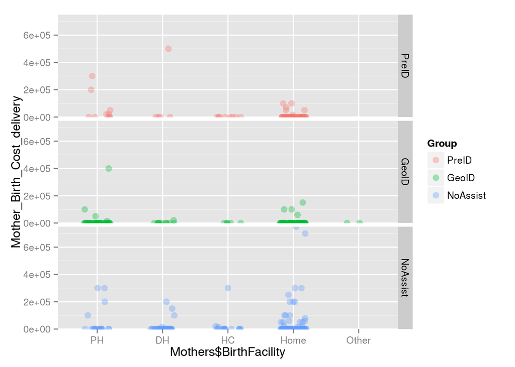

### 3.2.3 Birth Food Allowance

```r
##Hospital Births
hb <- sapply(levels(lps$Group),function(G) {
  sum(!is.na(subset(Mothers,BirthFacility %in% c("PH","DH")&Group==G)
             [,c("Mother_Birth_Hospital_Food_allowance")]))
})
hb
```

```
##    PreID    GeoID NoAssist
##       29       13       90
```

```r
##Got Food Allowance
fa <- sapply(levels(lps$Group),function(G) {
  sum(subset(Mothers,BirthFacility %in% c("PH","DH")&Group==G)
             [,c("Mother_Birth_Hospital_Food_allowance")]==1,na.rm=T)
})
fa
```

```
##    PreID    GeoID NoAssist
##        8       10        8
```

```r
##Percent Got Food Allowance
print(100*fa/hb,digits=1)
```

```
##    PreID    GeoID NoAssist
##       28       77        9
```

Serial Number 34 fails to report the food allowance information

#### 3.2.3.1 Plot Food Allowance Reciept for Hospital Births

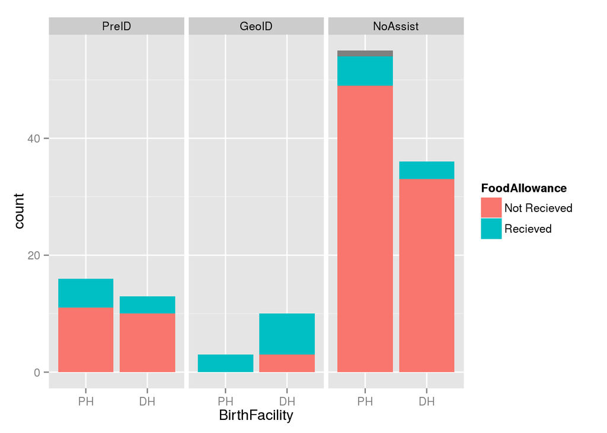

### 3.2.4 Transportation

#### 3.2.4.1 Plot Transportation Amount Recieved

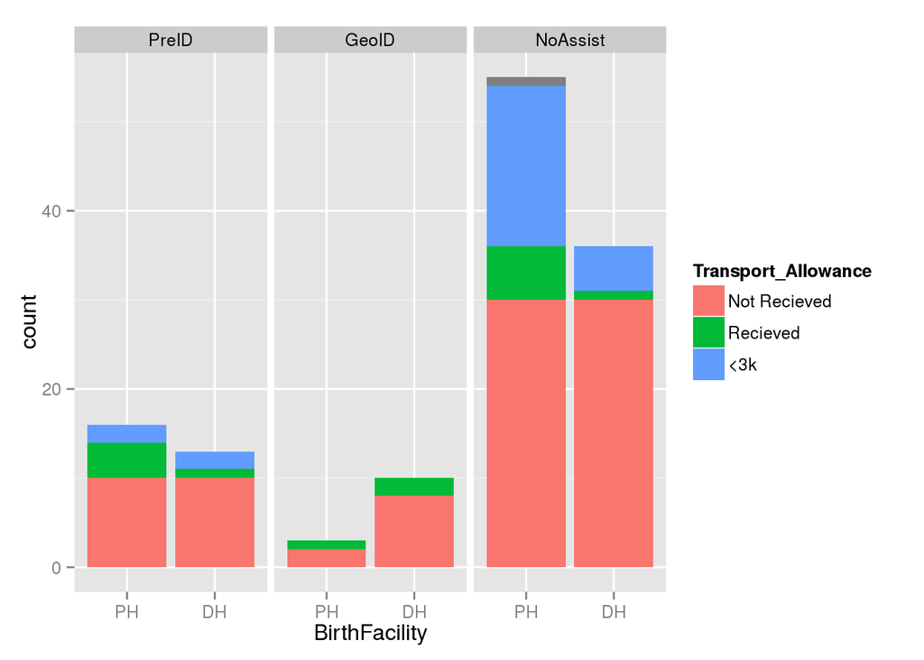

#### 3.2.4.2 Compare Transportation Allowance to previous

```r
CAAB <- subset(Mothers,Serial %in% CA$Serial & BirthFacility %in% c("PH","DH"))

##Compare Transportation Allowance to Child Addmitance Transportation Allowance
##CA is in rows Birth is in columns
table(subset(CA,Serial %in% CAAB$Seria)$Transport_Allowance,CAAB$Transport_Allowance)
```

```
##
##                Not Recieved Recieved <3k
##   Not recieved           11        1   1
##   Recieved                1        2   0
##   <3k                     0        0   1
```

### 3.2.5 (5.18, 5.23, 5.28)

## 3.3 HEF OOP expenditure

### 3.3.1 (Q8.8-8.16)